# Exercise - Tracks

Mirko Mälicke

# 1 SOLUTION

** THIS IS THE SOLUTION **

# 2 Description

**This is not a mandatory exercise. You can do this exercise in case you want more exercise using PostGIS.**

In case you need more practice with PostGIS, this exercise is perfect. It will force you to work on way larger datasets and go beyond the level of the PostGIS lecture. It does not include any environmental data, thus you will be forced to think outside your comfort zone of time-series data.

# 3 Tracks

This exercise is about tracks. The important data table is *track_points* which includes GPS coordintes from my personal Sport-GPS-Watch that I usually wear when I am doing sports. Let’s have a look on this table.

```sql
select * from track_points limit 3
```

| ogc_fid | track_fid | track_seg_id | track_seg_point_id | ele | time | magvar | geoidheight | name | cmt | desc | src | link1_href | link1_text | link1_type | link2_href | link2_text | link2_type | sym | type | fix | sat | hdop | vdop | pdop | ageofdgpsdata | dgpsid | geometry |
| --- | --- | --- | --- | --- | --- | --- | --- | --- | --- | --- | --- | --- | --- | --- | --- | --- | --- | --- | --- | --- | --- | --- | --- | --- | --- | --- | --- |
| 34993 | 0 | 0 | 91 | 314.2 | 2016-09-19 13:52:29 | NA | NA | NA | NA | NA | NA | NA | NA | NA | NA | NA | NA | NA | NA | NA | NA | NA | NA | NA | NA | NA | 0101000020E61000006493FC885F811F4098512CB7B4024840 |
| 34994 | 0 | 0 | 92 | 314.2 | 2016-09-19 13:52:37 | NA | NA | NA | NA | NA | NA | NA | NA | NA | NA | NA | NA | NA | NA | NA | NA | NA | NA | NA | NA | NA | 0101000020E61000000E2E1D739E811F40F304C24EB1024840 |
| 34995 | 0 | 0 | 93 | 314.2 | 2016-09-19 13:52:46 | NA | NA | NA | NA | NA | NA | NA | NA | NA | NA | NA | NA | NA | NA | NA | NA | NA | NA | NA | NA | NA | 0101000020E6100000C442AD69DE811F401E34BBEEAD024840 |

You see, that each coordinate is labeled with the elevation (*ele*) and the time of recording. These information along with some basic assumptions and a analysis of the actual locations are already enough to reconstruct the tracks I was using and analyze my training performance.

**CAUTION:** As you can already see here, this data is quite personal. I am still sharing this with you in order to foster your learing, but please be sensible with it. A commercial usage of this data is not permitted.

# 4 Reconstructing the tracks

PostGIS has a *ST_MakeLine* function, which can construct a *LineString* from a series of points. In Combining this to the assumption, that I have only one activity per day, we can aready construct the tracks.

```sql
select date_trunc('day', time) as day, st_makeline(geometry) from track_points  group by day limit 3
```

| day | st_makeline |
| --- | --- |
| 2015-09-24 | 0102000020E610000064010000AA45443179731F40E9B7AF03E7024840E3…… |
| 2015-09-28 | 0102000020E61000007A010000373811FDDA7A1F4020EC14AB06034840E6…… |
| 2015-10-05 | 0102000020E6100000E80000008693347F4C6B1F40001E51A1BA014840DB…… |

That seems to work. PostGIS can also calculate the lengths.

```sql
select date_trunc('day', time) as day, st_length(st_makeline(geometry)) from track_points  group by day limit 3
```

| day | st_length |
| --- | --- |
| 2015-09-24 | 0.4550602 |
| 2015-09-28 | 0.3993591 |
| 2015-10-05 | 0.3014048 |

Very typical error. GPS coordinates are always unprojected WGS84, that means this length has the unit degree, which does not make any sense. Therefore we have to transform it first.

```sql
select date_trunc('day', time) as day, st_length(st_transform(st_makeline(geometry), 25832)) from track_points  group by day limit 3
```

| day | st_length |
| --- | --- |
| 2015-09-24 | 37291.13 |
| 2015-09-28 | 33295.69 |
| 2015-10-05 | 32670.53 |

Yes I remember. This 37 km run on September, 24 2015 was really horrible. Luckily I did only a 33 km trip next time.  
Of course there was something wrong. GIS tends to do exactly what you told them. Here, the MakeLine function takes the points and connects them to a line. But to reconstruct the track, there is a ordering in the track. Therefore we need to know which point was taken first and which one was taken last. This is what the *track_seg_point_id* is made for.

```sql
select day, st_length(st_makeline(g)) as length from
(select date_trunc('day', time) as day, st_transform(geometry, 25832) as g from track_points  order by day, track_seg_point_id ASC) as t
group by day order by day ASC
limit 3
```

| day | length |
| --- | --- |
| 2015-09-24 | 3379.178 |
| 2015-09-28 | 3398.174 |
| 2015-10-05 | 1923.030 |

Now, it’s your turn as these runs seem to be correct in length.

# 5 Basic statistics

How could you add the activity duration?

If you substract a timestamp from another timestamp, the result will be of *interval* data type. This is a valid data type and postgres offers a number of functions to work with time intervals. This exercise part is maybe easier than you think.

```sql
select day, st_length(st_makeline(g)) as length, max(time) - min(time) as duration from
(select
  date_trunc('day', time) as day,
  st_transform(geometry, 25832) as g,
  time
  from track_points  order by day, track_seg_point_id ASC
) as t
group by day order by day ASC
limit 3
```

| day | length | duration |
| --- | --- | --- |
| 2015-09-24 | 3379.178 | 00:21:15 |
| 2015-09-28 | 3398.174 | 00:20:32 |
| 2015-10-05 | 1923.030 | 00:25:49 |

Once you have this (the first three runs I ever did took about 20 minutes.) create a temporary table of your results.

```sql
create temporary table tracks as
select day, st_length(st_makeline(g)) as length, max(time) - min(time) as duration from
(select
  date_trunc('day', time) as day,
  st_transform(geometry, 25832) as g,
  time
  from track_points  order by day, track_seg_point_id ASC
) as t
group by day order by day ASC
```

```sql
select * from tracks limit 3
```

| day | length | duration |
| --- | --- | --- |
| 2015-09-24 | 3379.178 | 00:21:15 |
| 2015-09-28 | 3398.174 | 00:20:32 |
| 2015-10-05 | 1923.030 | 00:25:49 |

The most important performance indicator is the pace. This is the mean time per kilometer and is usualy given in minutes/kilometer. Query the new table and add the pace. You could also create a view including the pace or recreate the table including the pace.

```sql
select *, duration / (length / 1000) as pace from tracks limit 3
```

| day | length | duration | pace |
| --- | --- | --- | --- |
| 2015-09-24 | 3379.178 | 00:21:15 | 00:06:17.310674 |
| 2015-09-28 | 3398.174 | 00:20:32 | 00:06:02.547651 |
| 2015-10-05 | 1923.030 | 00:25:49 | 00:13:25.499838 |

Many non-professional runners consider 6 minutes per kilometer as their target pace for a half marathon or full marathon. How often did I reach this time how often not?

```sql
select count(*) as "< 06:00" from tracks where duration / (length / 1000) < '00:06:00'::interval
```

| < 06:00 |
| --- |
| 81 |

```sql
select count(*) as "> 06:00" from tracks where duration / (length / 1000) > '00:06:00'::interval
```

| > 06:00 |
| --- |
| 82 |

How do these numbers distribute between the different years?

```sql
select * from
(
  select date_trunc('year', day) as year, count(*) as "> 06:00"
  from tracks where duration / (length / 1000) > '00:06:00'::interval
  group by year
) a
natural join
(
  select date_trunc('year', day) as year, count(*) as "< 06:00"
  from tracks where duration / (length / 1000) < '00:06:00'::interval
  group by year
) b
order by a.year DESC
```

| year | > 06:00 | < 06:00 |
| --- | --- | --- |
| 2018-01-01 | 4 | 1 |
| 2017-01-01 | 44 | 26 |
| 2016-01-01 | 31 | 54 |

Seems like I got worse, doesn’t it? Or did I just choose longer distances?

```sql
select date_trunc('year', day) as year, avg(length) as distance from tracks group by year order by year DESC
```

| year | distance |
| --- | --- |
| 2018-01-01 | 7002.872 |
| 2017-01-01 | 6556.470 |
| 2016-01-01 | 5838.667 |
| 2015-01-01 | 2900.127 |

# 6 Going beyond length and time

Maybe the distances do not improve the same as the times get slower. It could also be the elevation. Reconstructing the elevation profile is a bit more tricky. Let’s simplify this and look only at one track. There is the concept of window functions in Postgres, which we can utilize to query from a ordered window that is nothing else but the actual track itself. Using the function *LAG()* for the previous or *LEAD()* for the next value makes the trick.  
Let’s select one track and show the previous value and the change in elevation for each track point.

```sql
select ogc_fid, ele, time, lag(ele, 1) over w as previous, ele - lag(ele, 1) over w as difference
from track_points where date_trunc('day', time)='2016-09-23'
WINDOW w as (order by track_seg_point_id ASC)
```

| ogc_fid | ele | time | previous | difference |
| --- | --- | --- | --- | --- |
| 35927 | 250.5 | 2016-09-23 14:25:43 | NA | NA |
| 35341 | 250.5 | 2016-09-23 14:25:43 | 250.5 | 0.0 |
| 35928 | 250.0 | 2016-09-23 14:25:51 | 250.5 | -0.5 |
| 35342 | 250.0 | 2016-09-23 14:25:51 | 250.0 | 0.0 |
| 35343 | 250.0 | 2016-09-23 14:25:52 | 250.0 | 0.0 |
| 35929 | 250.0 | 2016-09-23 14:25:52 | 250.0 | 0.0 |
| 35344 | 250.0 | 2016-09-23 14:26:35 | 250.0 | 0.0 |
| 35930 | 250.0 | 2016-09-23 14:26:35 | 250.0 | 0.0 |
| 35345 | 248.6 | 2016-09-23 14:26:40 | 250.0 | -1.4 |
| 35931 | 248.6 | 2016-09-23 14:26:40 | 248.6 | 0.0 |

[output cut: 990 more lines]

Try to understand what this *over* does then you should be able to recalculate the tracks including the sum of **positive** elevation change. Search the documentation for the *with* environment and the partition keyword. Query the points by WITH and lay the window over the partition where the day stays the same.

Below, the exercise does get a bit more tricky and difficult. You will need some concepts about SQL, which were not introducted in the lectures. Use [StackOverflow](https://stackoverflow.com) or the PostgreSQL [documentation](https://www.postgresql.org/docs/)

```sql
with points as (
  select
    date_trunc('day', time) as day,
    ele,
    ele - lag(ele) over (partition by date_trunc('day', time) order by track_seg_point_id) as diff,
    st_transform(geometry, 25832) as g,
    time
  from track_points order by day, track_seg_point_id ASC
)
select
  day,
  st_length(st_makeline(g)) as distance,
  max(time) - min(time) as duration,
  (max(time) - min(time)) / (st_length(st_makeline(g)) / 1000) as pace,
  max(ele) as max_ele,
  sum(case when diff > 0 then diff else 0 end) as pos_ele
from points
group by day
order by day
```

| day | distance | duration | pace | max_ele | pos_ele |
| --- | --- | --- | --- | --- | --- |
| 2015-09-24 | 3379.1782 | 00:21:15 | 00:06:17.310674 | 314.0 | 93.5 |
| 2015-09-28 | 3398.1740 | 00:20:32 | 00:06:02.547651 | 314.0 | 95.0 |
| 2015-10-05 | 1923.0296 | 00:25:49 | 00:13:25.499838 | 273.0 | 30.6 |
| 2016-06-05 | 2073.3133 | 00:11:15 | 00:05:25.565849 | 257.9 | 18.6 |
| 2016-06-07 | 4957.3271 | 00:31:43 | 00:06:23.876223 | 330.7 | 128.2 |
| 2016-06-09 | 3563.3250 | 00:21:10 | 00:05:56.408688 | 314.0 | 96.3 |
| 2016-06-11 | 4992.2749 | 00:30:05 | 00:06:01.558613 | 314.0 | 112.2 |
| 2016-06-12 | 5009.1394 | 00:29:18 | 00:05:50.958493 | 314.0 | 112.1 |
| 2016-06-14 | 5059.2979 | 00:28:01 | 00:05:32.259543 | 314.0 | 111.0 |
| 2016-06-15 | 5611.7089 | 00:30:29 | 00:05:25.92567 | 314.0 | 125.4 |

[output cut: 153 more lines]

If that looks fine, either join the result to the old track table or create a new one.

```sql
create temporary table extended_tracks as
with points as (
  select
    date_trunc('day', time) as day,
    ele,
    ele - lag(ele) over (partition by date_trunc('day', time) order by track_seg_point_id) as diff,
    st_transform(geometry, 25832) as g,
    time
  from track_points order by day, track_seg_point_id ASC
)
select
  day,
  st_length(st_makeline(g)) as distance,
  max(time) - min(time) as duration,
  (max(time) - min(time)) / (st_length(st_makeline(g)) / 1000) as pace,
  max(ele) as max_ele,
  sum(case when diff > 0 then diff else 0 end) as pos_ele
from points
group by day
order by day
```

Now, to complte the previous analysis: The percentage of runs below a pace of 6 minutes drops over the years (2016 and 2017), while the distance did not increase that much. Does the sum of positive elevation change significantly?

```sql
select date_trunc('year', day) as year, sum(pos_ele) as total_pos_heigh, sum(pos_ele) / count(day) as "pos. ele / run"
from extended_tracks group by year order by year DESC
```

| year | total_pos_heigh | pos. ele / run |
| --- | --- | --- |
| 2018-01-01 | 1651.3 | 330.26000 |
| 2017-01-01 | 12048.7 | 172.12429 |
| 2016-01-01 | 14736.1 | 173.36588 |
| 2015-01-01 | 219.1 | 73.03333 |

Nope.

# 7 General overviews

Finally we produced a nice overview table. Now, let’s query some more general statistics and stream some results back to R. First, use the numbers from above for creating a violin plot (or box plot).

```sql
select date_trunc('year', day) as year, pos_ele
from extended_tracks order by year DESC
```

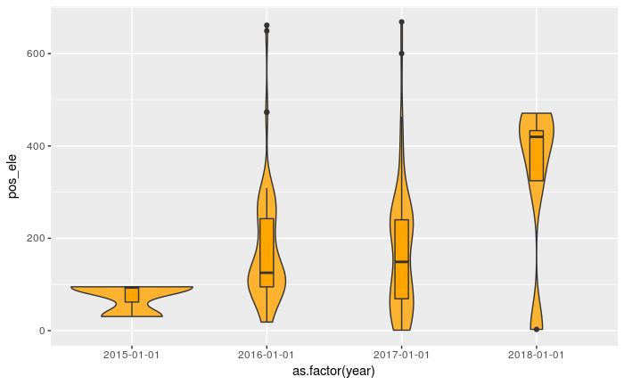

```r
ele.a %>%
  ggplot(aes(x=as.factor(year), y=pos_ele)) +
    geom_violin(fill='orange', alpha=0.8) +
    geom_boxplot(width=0.1, fill='orange')
```

Lastly, there might be an influence on the performance based on the month of the year. Maybe I do only imporve when it’s not too cold and not too hot.

```sql
select to_char(day, 'Mon') as month, extract('epoch' from pace) as pace from extended_tracks
```

```
Ignoring unknown parameters: trim
```

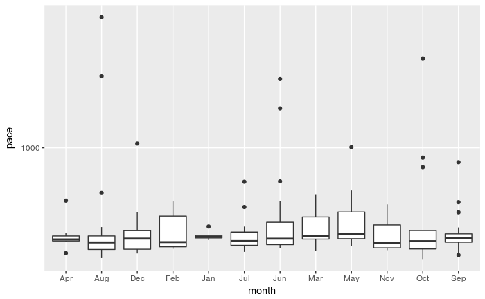

```r
ele.m %>%
  ggplot(aes(x=month, y=pace)) +
  geom_boxplot(trim=T) +
  scale_y_log10()
```

```r
#ele.m
```

```
Ignoring unknown parameters: trim
```

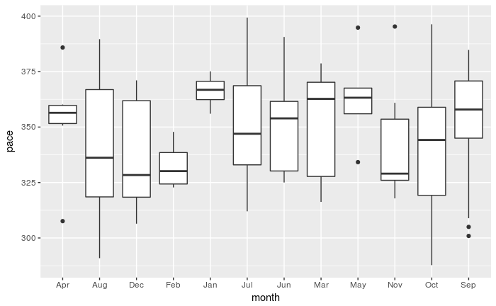

```r
ele.m %>%
  filter(pace <= 400) %>%
  ggplot(aes(x=month, y=pace)) +
  geom_boxplot(trim=T)
```

Last but not least: Calculate the overall statistics. The total distance, duration, mean pace and total positive elevation gains.

```sql
select
  round(sum(distance) / 1000) || ' km' as distance,
  sum(duration) as duration,
  to_char(avg(pace), 'MI:SS') as pace,
  sum(pos_ele) || ' m' as ele_gain
from extended_tracks
```

| distance | duration | pace | ele_gain |
| --- | --- | --- | --- |
| 999 km | 113:25:28 | 07:40 | 28655.2 m |

# 8 cleanup

```r
dbDisconnect(con)
```

```
[1] TRUE
```